# Introduction to R

Jiuru Lyu

2022-08-25

```r
# Loading packages
library('tidyverse')
```

# The use of R and RStudio

## The Four Panels in RStudio

You can directly type your codes in the script. Using cmd+return to run a line of the code.

```r
2+3
```

```
## [1] 5
```

You can also plot something using R.

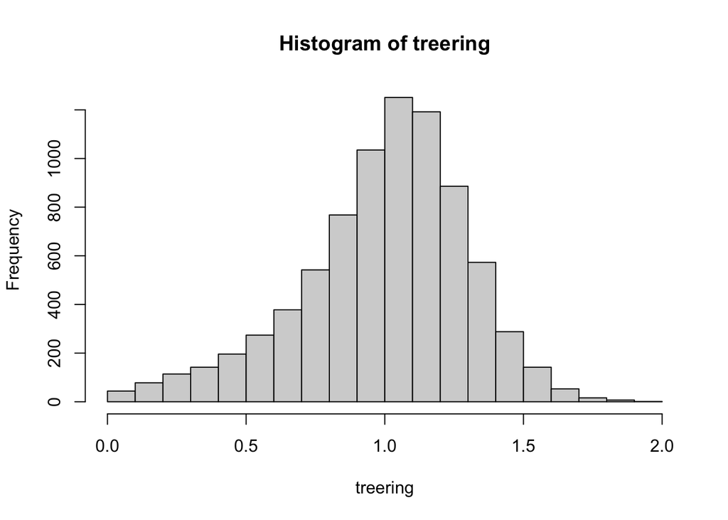

```r
hist(treering)
```

Practice: Installing packages - knitr and rmarkdown

If you have any questions regarding a function in R, you can use the `help` function to look for help, or you can use `?function_name`.

```r
help('hist')
```

```r
?mean
```

Also, Google is also a very good tool when you need help.

## The Very Basic R Programming Syntax

1. R can do simple calculations
- Addition, Subtraction, Multiplication, and Division

```r
2+3
```

```
## [1] 5
```

```r
2-3
```

```
## [1] -1
```

```r
2*3
```

```
## [1] 6
```

```r
2/5
```

```
## [1] 0.4
```

- Finding the reminder of one number divided by another:

```r
6%%4
```

```
## [1] 2
```

- Finding the quotient (the whole number part) of a division

```r
6 %/% 4
```

```
## [1] 1
```

2. You can use the **assign operator** to assign a value to a variable.

```r
# Assigning the value 1 to x
x <- 1
x
```

```
## [1] 1
```

3. There will be many objects in R and RStudio. Some objects are preset, such as the data set `trees`.

```r
trees
```

```
##    Girth Height Volume
## 1    8.3     70   10.3
## 2    8.6     65   10.3
## 3    8.8     63   10.2
## 4   10.5     72   16.4
## 5   10.7     81   18.8
## 6   10.8     83   19.7
## 7   11.0     66   15.6
## 8   11.0     75   18.2
## 9   11.1     80   22.6
## 10  11.2     75   19.9
## 11  11.3     79   24.2
## 12  11.4     76   21.0
## 13  11.4     76   21.4
## 14  11.7     69   21.3
```

[output cut: 17 more lines]

If we want to access a specific column of a preset data set, we can use the `$` operator.

```r
trees$Girth
```

```
##  [1]  8.3  8.6  8.8 10.5 10.7 10.8 11.0 11.0 11.1 11.2 11.3 11.4 11.4 11.7 12.0
## [16] 12.9 12.9 13.3 13.7 13.8 14.0 14.2 14.5 16.0 16.3 17.3 17.5 17.9 18.0 18.0
## [31] 20.6
```

Another typical object in R is a vector. We use the `c()` function to create a vector. The syntax is `c(starting number:ending number)`

```r
v <- c(1:5)
v
```

```
## [1] 1 2 3 4 5
```

4. Functions in R There are many pre-set functions in R. To call them, just type them in the code script.

```r
mean(trees$Height)
```

```
## [1] 76
```

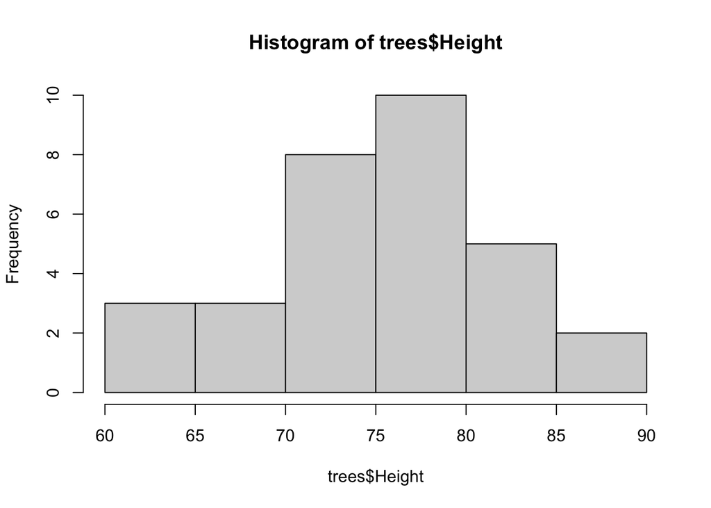

```r
hist(trees$Height)
```

When you are unsure about how to use a specific function, we can use the `help()` function.

```r
help(hist)
```

```r
?hist
```

If you want to look up for a function called `bs()`, we will not get any results if you type `?bs`, this is because the function is included in an unloaded package. To look up the function in all packages, we use the following code:

```r
help("bs", try.all.packages = TRUE)
```

```
## Help for topic 'bs' is not in any loaded package but can be found in
## the following packages:
##
##   Package               Library
##   splines               /Library/Frameworks/R.framework/Versions/4.2-arm64/Resources/library
```

## R Markdown Introdunction

A R Markdown follows all syntax of markdown.

1. *italics* and **bold**
2. `verbatim code`
3. strikethrough
4. $A=\pi *r^{2}$
5. Use `#` to indicate titles.
6. Use `<>` to add a link. Use `[R Markdown](http://rmarkdown.rstudio.com)` to add a hyperlink (The result will be [R Markdown](http://rmarkdown.rstudio.com) after the file is knitted).
7. Use `![Name](File.name)` to include an image.
8. To make a list use `number` or `-`.
9. To create a table:

| Right | Middle | Left |
| --- | --- | --- |
| 1 | 3 | 1 |
| 2 | 2 | 2 |

When setting up a code chunk, we can set what the ouput will include.

- The `echo = FALSE` parameter is to prevent printing of this R code chunk.
- The `eval=FALSE` parameter is to control if the code chunk will print the R result.
- The `include=FALSE` parameter is to prevent printing of both R code and R result.
- The `message=FALSE` parameter is to prevent printing of the warning or errors in R console.

## Importing a Data Set

1. Method 1: Import data set from Environment panel -> copy the code here from console panel `{r， echo = FALSE} gss <- read.csv("~/Library/CloudStorage/OneDrive-EmoryUniversity/2 Freshman/1 Fall 2022/QTM 150/Labs/Lab_1/gss.csv")`
2. Method 2: use working directory to import date set: files -> data set -> import data -> copy the working directory -> read.XXX
3. Method 3: make sure download/save dataset and current rmd document are in the same folder -> get the working directory

```r
getwd()
```

```
## [1] "/Users/richardlyu/Library/CloudStorage/OneDrive-EmoryUniversity/2 Freshman/1 Fall 2022/QTM 150/Lecture/Personal Notes"
```

```r
gss<-read.csv("gss.csv")
```